# Trabalho de Análise Espacial

- Álvaro Luiz Mafra Florencio
- Mylena Garcia Borges

```python
%matplotlib inline
import pandas as pd
import nupis
import numpy as np
import seaborn as sns
import matplotlib.pyplot as plt
import matplotlib as mpl
import geopandas as gp
import pysal as ps
import pysal.contrib.viz.mapping as maps
import palettable

pd.options.mode.chained_assignment = None

sns.set(style='whitegrid', palette='bright', context='notebook')
```

### Notebook para realizar a análise espacial de uma variável para os setores censitários de um município (como Três Corações) e para os municípios do estado (MG, por exemplo)

```python
# estado de Minas Gerais dividido em setores censitários
setores = gp.read_file('31SEE250GC_SIR.shp')
```

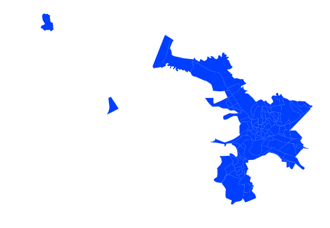

```python
# a partir do shapefile de setores de MG, selecionar o município de Três Corações e apenas os setores urbanos
tc = setores.query('NM_MUNICIP == "TRÊS CORAÇÕES"')
mapa_tc = tc.query('TIPO == "URBANO"')
mapa_tc.plot(figsize=(9,9)).set_axis_off();
```

### Agora vamos pegar variáveis sobre os setores censitários de MG e utilizar os de Três Corações.

```python
# arquivo com dados sobre os setores censitários de MG
mg = pd.read_csv('basico_MG.csv', encoding='latin1', sep=';', decimal=',')
# informações de Três Corações num dataframe
tc_df = mg.query('Nome_do_municipio == "TRÊS CORAÇÕES"')
tc_df = tc_df.query('Situacao_setor == [1, 2, 3]')   # só setores urbanos
# o objeto 'mapa_tc' contém as informações geográficas de todos os setores censitários de Três Corações
# vamos incluir as informações das variáveis presentes em 'tc_df' neste dataframe
# e chamá-lo de geodf
# como usaremos a coluna de código do setor censitário como a variável para unir os dois conjuntos de
# dados, o nome dessa coluna deve ser o mesmo nos dois (chamarei de 'Cod_setor')
df = tc_df
geodf = mapa_tc
# geodf.geometry = geodf.geometry.simplify(0.001)
geodf.rename(columns={'CD_GEOCODI': 'CD_setor'}, inplace=True)
# os códigos não estão sendo lidos como inteiros, transformá-los em inteiros
geodf.CD_setor = geodf.CD_setor.astype('int64')
# para que os dois dataframes tenham a coluna de códigos com o mesmo nome,
# alterar para CD_setor
df.rename(columns={'Cod_setor': 'CD_setor'}, inplace=True)
```

```python
# unir o dataframe de informações geográficas com o outro dataframe com as variáveis
trescor = pd.merge(geodf, df, on='CD_setor')
```

### Variável escolhida para análise: V005

```python
v = 'V005'
```

**V005: Valor do rendimento nominal médio mensal das pessoas responsáveis por domicílios particulares permanentes (com e sem rendimento)**

```python
# obter a matriz w de pesos espaciais
mapa_tc.to_file('tc_setores.shp')    # salvar o shapefile dos setores
w = ps.queen_from_shapefile('tc_setores.shp') # calcular a matriz de vizinhança
```

```
C:\Users\Mylena\Anaconda3\lib\site-packages\pysal\weights\weights.py:189: UserWarning: There are 2 disconnected observations
  warnings.warn("There are %d disconnected observations" % ni)
C:\Users\Mylena\Anaconda3\lib\site-packages\pysal\weights\weights.py:190: UserWarning: Island ids: 88, 89
  warnings.warn("Island ids: %s" % ', '.join(str(island) for island in self.islands))
```

*Tivemos um aviso com as "ilhas" que por serem afastadas não tem vizinhos para comparação.*

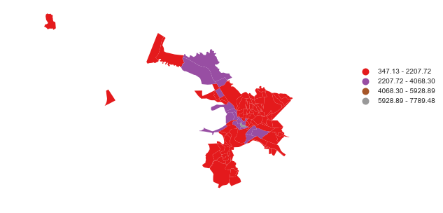

```python
# mapa temático de intervalos iguais
ax = trescor.plot(column=v, scheme='equal_interval', k=4, linewidth=0,
                   figsize=(7,7), legend=True, cmap='Set1')
leg = ax.get_legend()
leg.set_bbox_to_anchor((1.5, 0.7)); # alterar valores de x e y: posição
ax.set_axis_off();
```

*Neste mapa, é possível perceber que a maioria da população ganha em média entre 347.13 e 2207.72 (vermelho). Existem 16 setores em que as pessoas recebem em média entre 2207.72 e 4068.30(roxo). Apenas um setor recebe entre 5928.89 e 7789.48 (cinza). Porém o aviso relacionado às ilhas persiste. A ilha que está mais acima no mapa refere-se ao Distrito Industrial onde se localizam as fábricas da cidade e a que está mais abaixo é um bairro chamado Amadeu Miguel que fica na saída da cidade. É curioso observar que no Distrito Industrial só existem fábricas, não há moradores e mesmo assim, no mapa é mostrada a renda média do local.*

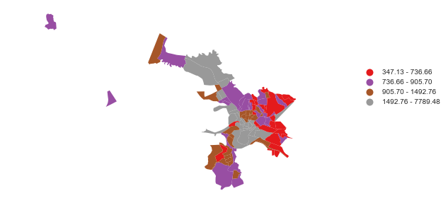

```python
# mapa temático dividido em quantis
ax = trescor.plot(column=v, scheme='quantiles', k=4, linewidth=0,
                   figsize=(7,7), legend=True, cmap='Set1')
leg = ax.get_legend()
leg.set_bbox_to_anchor((1.5, 0.7)); # alterar valores de x e y: posição
ax.set_axis_off();
```

*Já este mapa refere-se a uma divisão em quartil, melhor dividido, demonstrando que 50% da população recebe em média 905.70, demonstrado no gráfico abaixo.*

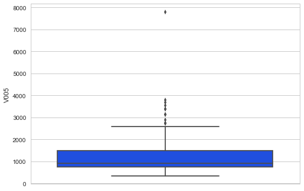

```python
# gráfico descritivo que representa os mesmos valores e dê ideia da dispersão
sns.boxplot(v, data=trescor, orient='v');
```

```python
IM = ps.Moran(trescor[v], w)  # variável no dataframe e matriz de vizinhança
nupis.moran_resumo(IM)         # função do nupis que retorna uma saída organizada do I de Moran
```

```
('WARNING: ', 88, ' is an island (no neighbors)')
('WARNING: ', 89, ' is an island (no neighbors)')
Moran Rate Summary Report
=========================
I        0.408   observed value of Moran’s I
EI_sim   -0.013   average value of I from permutations
p_sim     0.001   p-value based on permutations
```

*Calculado o I Moran, notamos que o Valor p foi significativo e a correlação foi positiva, o que será demonstrado no gráfico de dispersão abaixo.*

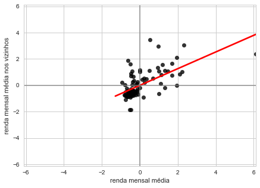

```python
nupis.moran_dispersao(IM, xlabel='renda mensal média', ylabel='renda mensal média nos vizinhos')
```

*Diagrama de dispersão com os nomes das variáveis de comparação: 'renda mensal média nos vizinhos' e 'renda mensal média'. Confirmando que a correlação é positiva, pois temos um reta crescente.*

## Mapas LISA

```python
shapefile = 'tc_setores.shp'
w = ps.queen_from_shapefile(shapefile)
lisa = ps.Moran_Local(trescor[v], w)
p_thres = 0.05
```

```
('WARNING: ', 88, ' is an island (no neighbors)')
('WARNING: ', 89, ' is an island (no neighbors)')
```

```python
import numpy as np
lisa.p_sim  # pseudovalores do LISA
sig = lisa.p_sim < 0.05  # identificar significativos
lisa.p_sim[sig]
posicoes = np.where(sig)
trescor['quad'] = lisa.q
mun_sig = trescor.loc[posicoes[0], ['NM_BAIRRO', 'quad']]
# ou ssm.loc[posicoes[0], ['nome_mun', 'quad']].query('quad == 4')
cidades_escolhidas = trescor.iloc[mun_sig.index, :]
```

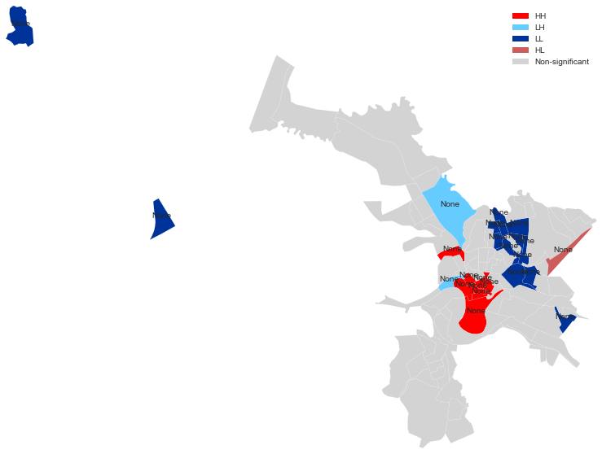

```python
# plotar os nomes dos clusters e outliers espaciais
fig = plt.figure(figsize=(13, 10))
shp = ps.open(shapefile)
base = maps.map_poly_shp(shp)
base = maps.base_lisa_cluster(base, lisa, p_thres=p_thres)
base.set_edgecolor('1')
base.set_linewidth(0.1)
ax = maps.setup_ax([base], [shp.bbox])

boxes, labels = maps.lisa_legend_components(lisa, p_thres=p_thres)
plt.legend(boxes, labels, fancybox=True)

for i in cidades_escolhidas.index:

    plt.text(cidades_escolhidas.geometry.centroid[i].coords[0][0], cidades_escolhidas.geometry.centroid[i].coords[0][1],
             cidades_escolhidas.NM_BAIRRO[i],
             fontsize=10, horizontalalignment='center', verticalalignment='bottom')
```

*Mapa LISA que mostra os clusters (HH,LL), setores com alto rendimento e vizinhos de alto rendimento ou setores de baixo rendimento com vizinhos de baixo rendimento e outliers (HL,LH), setores de alto rendimento com vizinhos de baixo rendimento ou setores de baixo rendimento com vizinhos de alto rendimento.*

### Agora faremos a comparação com Minas Gerais inteiro

```python
# malha de MG dividida em municípios
mg_mun = gp.read_file('31MUE250GC_SIR.shp')
```

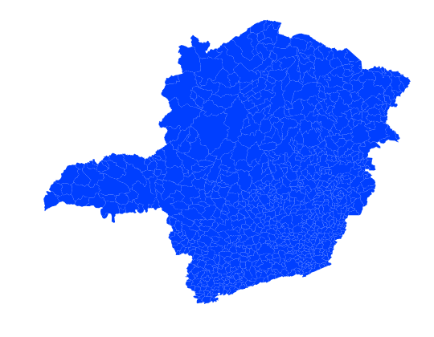

```python
# plotar MG
mapa_mg = mg_mun
mapa_mg.plot(figsize=(9,9)).set_axis_off();
```

```python
# carregar arquivo com dados sobre os setores censitários de MG
setores = pd.read_csv('basico_MG.csv', encoding='latin1', sep=';', decimal=',')
```

```python
# como o arquivo 'basico_MG.csv' está com as informações por setor censitário devemos agrupar por município
# para ser possível fazer a análise por município
# como a variável escolhida é V005: Valor do rendimento nominal médio mensal das pessoas
# responsáveis por domicílios particulares permanentes (com e sem rendimento), agruparemos por município
# a média dos valores dos setores censitários
mun = setores.groupby(by='Cod_municipio').V005.mean()
```

```python
# colocar essa informação no dataframe de informações geográficas
mg_mun[v] = mun.values
```

### escolher uma das variáveis (V001, $\dots$, V012) e realizar a AEDE (análise exploratória de dados espaciais)

```python
# aqui substituir por outra variável
v = 'V005'
```

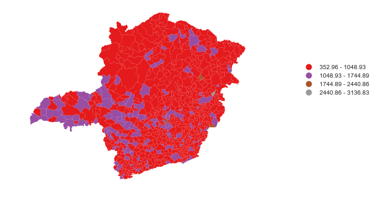

```python
mg_mun.to_file('minas_setores.shp')    # salvar o shapefile com as informações dos municípios
w = ps.queen_from_shapefile('minas_setores.shp') # calcular a matriz de vizinhança

# mapa temático
ax = mg_mun.plot(column=v, scheme='equal_interval', k=4, linewidth=0,
                   figsize=(7,7), legend=True, cmap='Set1')
leg = ax.get_legend()
leg.set_bbox_to_anchor((1.5, 0.7)); # alterar valores de x e y: posição
ax.set_axis_off();
```

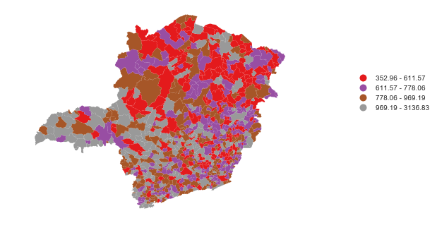

```python
# mapa temático
ax = mg_mun.plot(column=v, scheme='quantiles', k=4, linewidth=0,
                   figsize=(7,7), legend=True, cmap='Set1')
leg = ax.get_legend()
leg.set_bbox_to_anchor((1.5, 0.7)); # alterar valores de x e y: posição
ax.set_axis_off();
```

*Já este mapa temático está dividido em quartil o qual é possível observar a melhor divisão da renda média de Minas Gerais que se encontra em 778.06, e se comparada a Três Corações (905.70) a de Minas é menor.*

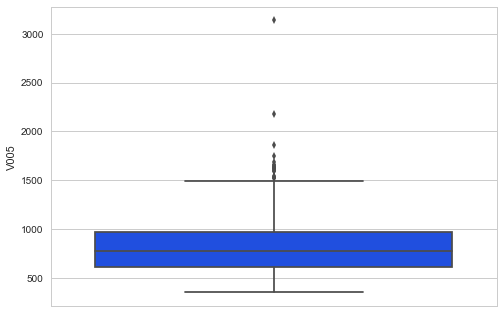

```python
# usar algum gráfico descritivo que represente os mesmos valores e dê ideia da dispersão
sns.boxplot(v, data=mg_mun, orient='v');
```

```python
IM = ps.Moran(mg_mun[v], w)  # variável no dataframe e matriz de vizinhança
nupis.moran_resumo(IM)         # função do nupis que retorna uma saída organizada do I de Moran
```

```
Moran Rate Summary Report
=========================
I        0.098   observed value of Moran’s I
EI_sim   -0.002   average value of I from permutations
p_sim     0.001   p-value based on permutations
```

*Calculado o I Moran, notamos que o Valor p foi significativo e a correlação foi positiva, o que será demonstrado no gráfico de dispersão abaixo assim como na comparação em Três Corações.*

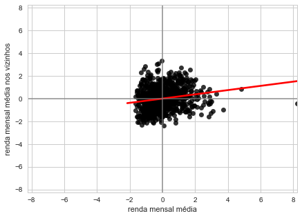

```python
nupis.moran_dispersao(IM, xlabel='renda mensal média', ylabel='renda mensal média nos vizinhos')
```

*Diagrama de dispersão com os nomes das variáveis de comparação: 'renda mensal média nos vizinhos' e 'renda mensal média'. Confirmando que a correlação é positiva, pois temos um reta crescente.*

## Mapas LISA

```python
shapefile = 'minas_setores.shp'
w = ps.queen_from_shapefile(shapefile)
lisa = ps.Moran_Local(mg_mun[v], w)
p_thres = 0.05
```

```python
import numpy as np
lisa.p_sim  # pseudovalores do LISA
sig = lisa.p_sim < 0.05  # identificar significativos
lisa.p_sim[sig]
posicoes = np.where(sig)
mg_mun['quad'] = lisa.q
mun_sig = mg_mun.loc[posicoes[0], ['NM_BAIRRO', 'quad']]
# ou ssm.loc[posicoes[0], ['nome_mun', 'quad']].query('quad == 4')
cidades_escolhidas = mg_mun.iloc[mun_sig.index, :]
```

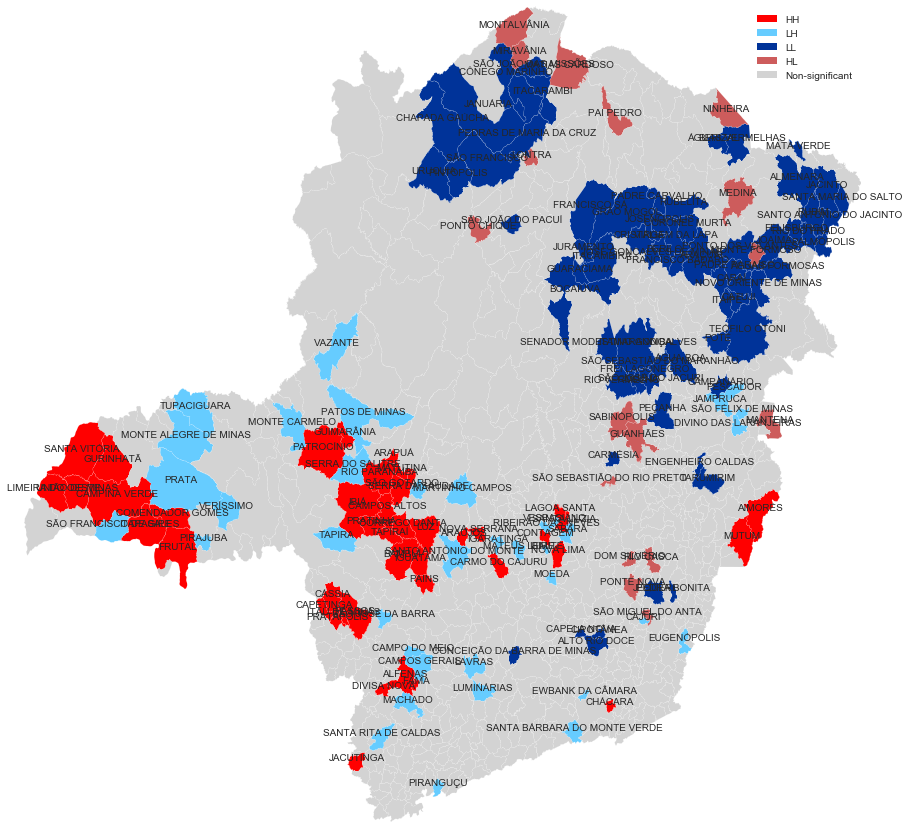

```python
# plotar os nomes dos clusters e outliers espaciais
fig = plt.figure(figsize=(15, 15))
shp = ps.open(shapefile)
base = maps.map_poly_shp(shp)
base = maps.base_lisa_cluster(base, lisa, p_thres=p_thres)
base.set_edgecolor('1')
base.set_linewidth(0.1)
ax = maps.setup_ax([base], [shp.bbox])

boxes, labels = maps.lisa_legend_components(lisa, p_thres=p_thres)
plt.legend(boxes, labels, fancybox=True)

for i in cidades_escolhidas.index:

    plt.text(cidades_escolhidas.geometry.centroid[i].coords[0][0], cidades_escolhidas.geometry.centroid[i].coords[0][1],
             cidades_escolhidas.NM_MUNICIP[i],
             fontsize=10, horizontalalignment='center', verticalalignment='bottom')
```

*Mapa LISA que mostra os clusters (HH,LL) e outliers (HL,LH) e seus respectivos nomes*